# CASE STUDY 1 : BIKE SHARING ANALYSES OF HOW CASUAL RIDERS DIFFER FROM MEMBER RIDERS

ISAAC AMOAH

2022-04-23

### Cyclistic is a bike sharing company that have about 5,824 bicycles located in 692 stations in Chicago. Their main customers are grouped into members and casuals riders. Member riders are people who have annual subscription while casual riders are people who buy passes such as sigle day or half day pass.

### The data is a large data set, this is the reason for using R which can deal with large data set. R has great data visualization and also help with calculations. The data is bicycle ride in 2021, from january to december. Data is loaded into R-studio for analysis

```r
library(readr)
Jan2021 <- read_csv("C:/Users/pcgg/Desktop/DATA ANALYST CERTIFICATE/DATA ANALYST DATA/202101-divvy-tripdata.csv")
Feb2021 <- read_csv("C:/Users/pcgg/Desktop/DATA ANALYST CERTIFICATE/DATA ANALYST DATA/202102-divvy-tripdata.csv")
Mar2021 <- read_csv("C:/Users/pcgg/Desktop/DATA ANALYST CERTIFICATE/DATA ANALYST DATA/202103-divvy-tripdata.csv")
Apr2021 <- read_csv("C:/Users/pcgg/Desktop/DATA ANALYST CERTIFICATE/DATA ANALYST DATA/202104-divvy-tripdata.csv")
May2021 <- read_csv("C:/Users/pcgg/Desktop/DATA ANALYST CERTIFICATE/DATA ANALYST DATA/202105-divvy-tripdata.csv")
Jun2021 <- read_csv("C:/Users/pcgg/Desktop/DATA ANALYST CERTIFICATE/DATA ANALYST DATA/202106-divvy-tripdata.csv")
Jul2021 <- read_csv("C:/Users/pcgg/Desktop/DATA ANALYST CERTIFICATE/DATA ANALYST DATA/202107-divvy-tripdata.csv")
Aug2021 <- read_csv("C:/Users/pcgg/Desktop/DATA ANALYST CERTIFICATE/DATA ANALYST DATA/202108-divvy-tripdata.csv")
Sep2021 <- read_csv("C:/Users/pcgg/Desktop/DATA ANALYST CERTIFICATE/DATA ANALYST DATA/202109-divvy-tripdata.csv")
Oct2021 <- read_csv("C:/Users/pcgg/Desktop/DATA ANALYST CERTIFICATE/DATA ANALYST DATA/202110-divvy-tripdata.csv")
Nov2021 <- read_csv("C:/Users/pcgg/Desktop/DATA ANALYST CERTIFICATE/DATA ANALYST DATA/202111-divvy-tripdata.csv")
Dec2021 <- read_csv("C:/Users/pcgg/Desktop/DATA ANALYST CERTIFICATE/DATA ANALYST DATA/202112-divvy-tripdata.csv")
bik_data <- rbind.data.frame(Jan2021,Feb2021,Mar2021,Apr2021,May2021,Jun2021,Jul2021,Aug2021,Sep2021,Oct2021,Nov2021,Dec2021)
```

###The data needs to be recoded, extrated for easy graphing and analysis. The day of the week, monthsare extrated from the start date. Also the duration of ride was calculated in minutes

```r
bik_data$weekday <- format(as.Date(bik_data$started_at), "%A")
bik_data$month_year <- format(as.Date(bik_data$started_at), "%b")
bik_data$hours <- format(as.POSIXct(bik_data$started_at), format = "%H")
bik_data$startdate <- as.POSIXct(bik_data$started_at)
bik_data$enddate <- as.POSIXct(bik_data$ended_at)
bik_data$minute_ride <- difftime(bik_data$enddate,bik_data$startdate, units = "mins")
```

###load packages that can help with data cleaning and graphs

```r
library(tidyverse)
library(lubridate)
library(janitor)
```

```r
library(ggplot2)
library(dplyr)
```

###Delete NA, which are ommitted variables. This are rides that are not taken or recorded. As well as clean the names in the data. There are negative and NA values in the data set. The time values have negative by inspection and finding the minimum and maximum

```r
max(bik_data$minute_ride)
```

```
## Time difference of 55944.15 mins
```

```r
min(bik_data$minute_ride)
```

```
## Time difference of -58.03333 mins
```

```r
bik_clean <- bik_data
bik_clean$minute_ride[bik_clean$minute_ride < 0] <- NA

bik_data_new <- na.omit(bik_clean)
```

##have a view of the data, the structure, the data type of each column. This helps make easy to know how to analyse the data.

```r
glimpse(bik_data_new)
```

```
## Rows: 4,588,186
## Columns: 19
## $ ride_id            <chr> "B9F73448DFBE0D45", "457C7F4B5D3DA135", "57C750326F~
## $ rideable_type      <chr> "classic_bike", "electric_bike", "electric_bike", "~
## $ started_at         <dttm> 2021-01-24 19:15:38, 2021-01-23 12:57:38, 2021-01-~
## $ ended_at           <dttm> 2021-01-24 19:22:51, 2021-01-23 13:02:10, 2021-01-~
## $ start_station_name <chr> "California Ave & Cortez St", "California Ave & Cor~
## $ start_station_id   <chr> "17660", "17660", "17660", "17660", "17660", "17660~
## $ end_station_name   <chr> "Wood St & Augusta Blvd", "California Ave & North A~
## $ end_station_id     <chr> "657", "13258", "657", "657", "657", "KA1504000135"~
## $ start_lat          <dbl> 41.90036, 41.90041, 41.90037, 41.90038, 41.90036, 4~
## $ start_lng          <dbl> -87.69670, -87.69673, -87.69669, -87.69672, -87.696~
## $ end_lat            <dbl> 41.89918, 41.91044, 41.89918, 41.89915, 41.89918, 4~
## $ end_lng            <dbl> -87.67220, -87.69689, -87.67218, -87.67218, -87.672~
## $ member_casual      <chr> "member", "member", "casual", "casual", "casual", "~
## $ weekday            <chr> "Sunday", "Saturday", "Saturday", "Saturday", "Sund~
## $ month_year         <chr> "Jan", "Jan", "Jan", "Jan", "Jan", "Jan", "Jan", "J~
## $ hours              <chr> "19", "12", "15", "15", "15", "15", "10", "11", "07~
## $ startdate          <dttm> 2021-01-24 19:15:38, 2021-01-23 12:57:38, 2021-01-~
## $ enddate            <dttm> 2021-01-24 19:22:51, 2021-01-23 13:02:10, 2021-01-~
## $ minute_ride        <drtn> 7.216667 mins, 4.533333 mins, 9.783333 mins, 8.950~
```

```r
head(bik_data_new)
```

```
## # A tibble: 6 x 19
##   ride_id rideable_type started_at          ended_at            start_station_n~
##   <chr>   <chr>         <dttm>              <dttm>              <chr>
## 1 B9F734~ classic_bike  2021-01-24 19:15:38 2021-01-24 19:22:51 California Ave ~
## 2 457C7F~ electric_bike 2021-01-23 12:57:38 2021-01-23 13:02:10 California Ave ~
## 3 57C750~ electric_bike 2021-01-09 15:28:04 2021-01-09 15:37:51 California Ave ~
## 4 4D518C~ electric_bike 2021-01-09 15:28:57 2021-01-09 15:37:54 California Ave ~
## 5 9D08A3~ classic_bike  2021-01-24 15:56:59 2021-01-24 16:07:08 California Ave ~
## 6 49FCE1~ electric_bike 2021-01-22 15:15:28 2021-01-22 15:36:01 California Ave ~
## # ... with 14 more variables: start_station_id <chr>, end_station_name <chr>,
## #   end_station_id <chr>, start_lat <dbl>, start_lng <dbl>, end_lat <dbl>,
## #   end_lng <dbl>, member_casual <chr>, weekday <chr>, month_year <chr>,
## #   hours <chr>, startdate <dttm>, enddate <dttm>, minute_ride <drtn>
```

```r
str(bik_data_new)
```

```
## tibble [4,588,186 x 19] (S3: tbl_df/tbl/data.frame)
##  $ ride_id           : chr [1:4588186] "B9F73448DFBE0D45" "457C7F4B5D3DA135" "57C750326F9FDABE" "4D518C65E338D070" ...
##  $ rideable_type     : chr [1:4588186] "classic_bike" "electric_bike" "electric_bike" "electric_bike" ...
##  $ started_at        : POSIXct[1:4588186], format: "2021-01-24 19:15:38" "2021-01-23 12:57:38" ...
##  $ ended_at          : POSIXct[1:4588186], format: "2021-01-24 19:22:51" "2021-01-23 13:02:10" ...
##  $ start_station_name: chr [1:4588186] "California Ave & Cortez St" "California Ave & Cortez St" "California Ave & Cortez St" "California Ave & Cortez St" ...
##  $ start_station_id  : chr [1:4588186] "17660" "17660" "17660" "17660" ...
##  $ end_station_name  : chr [1:4588186] "Wood St & Augusta Blvd" "California Ave & North Ave" "Wood St & Augusta Blvd" "Wood St & Augusta Blvd" ...
##  $ end_station_id    : chr [1:4588186] "657" "13258" "657" "657" ...
##  $ start_lat         : num [1:4588186] 41.9 41.9 41.9 41.9 41.9 ...
##  $ start_lng         : num [1:4588186] -87.7 -87.7 -87.7 -87.7 -87.7 ...
##  $ end_lat           : num [1:4588186] 41.9 41.9 41.9 41.9 41.9 ...
##  $ end_lng           : num [1:4588186] -87.7 -87.7 -87.7 -87.7 -87.7 ...
##  $ member_casual     : chr [1:4588186] "member" "member" "casual" "casual" ...
##  $ weekday           : chr [1:4588186] "Sunday" "Saturday" "Saturday" "Saturday" ...
##  $ month_year        : chr [1:4588186] "Jan" "Jan" "Jan" "Jan" ...
##  $ hours             : chr [1:4588186] "19" "12" "15" "15" ...
##  $ startdate         : POSIXct[1:4588186], format: "2021-01-24 19:15:38" "2021-01-23 12:57:38" ...
##  $ enddate           : POSIXct[1:4588186], format: "2021-01-24 19:22:51" "2021-01-23 13:02:10" ...
##  $ minute_ride       : 'difftime' num [1:4588186] 7.21666666666667 4.53333333333333 9.78333333333333 8.95 ...
##   ..- attr(*, "units")= chr "mins"
##  - attr(*, "na.action")= 'omit' Named int [1:1006877] 1 2 3 4 5 6 7 8 9 2465 ...
##   ..- attr(*, "names")= chr [1:1006877] "1" "2" "3" "4" ...
```

##Compare bike riding between casual and member customers ##The graph clearly shows members ride more than cansuals in the year 2021.

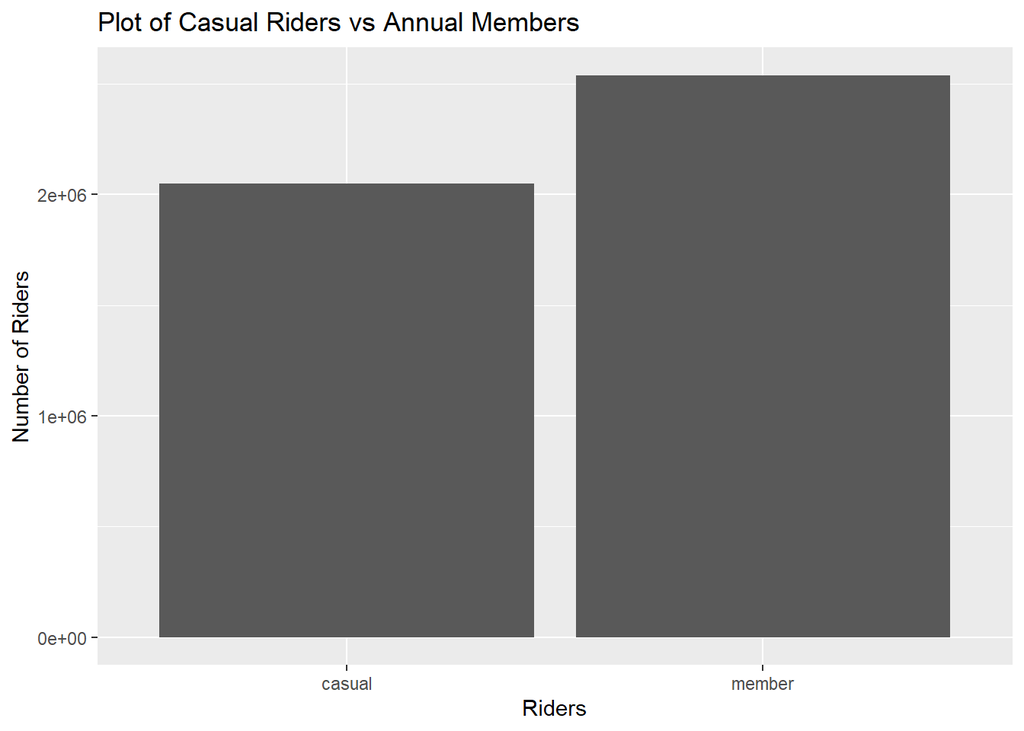

```r
ggplot(bik_data_new, aes(factor(member_casual),fill =(minute_ride))) + geom_bar() + ggtitle("Plot of Casual Riders vs Annual Members") +
  xlab("Riders") + ylab("Number of Riders")
```

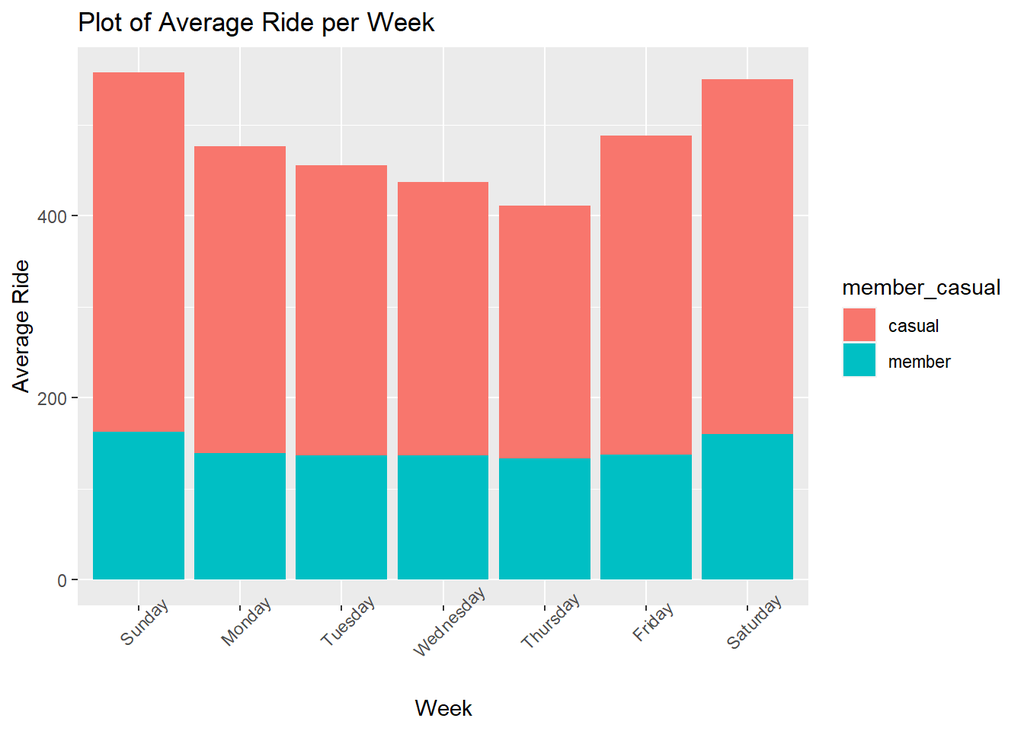

```r
bik_data_new$weekday <- ordered(bik_data_new$weekday, levels=c("Sunday", "Monday", "Tuesday", "Wednesday", "Thursday", "Friday", "Saturday"))

bik_data_new$month_year <- ordered(bik_data_new$month_year, levels=c("Jan", "Feb", "Mar", "Apr", "May", "June", "July","Aug","Sep","Oct","Nov","Dec"))


bik_plot<- bik_data_new %>% group_by(weekday,member_casual,month_year) %>%
summarise(average_ride=mean(minute_ride))
bik_plot1<-as.data.frame(bik_plot)

ggplot(bik_plot1, aes(fill=member_casual, y=average_ride, x=weekday)) +
  geom_bar(position="stack", stat="identity") + theme(axis.text.x = element_text(angle = 45)) + ggtitle("Plot of Average Ride per Week") +
  xlab("Week") + ylab("Average Ride")
```

## Docked bicycles are the most driven in all three categories of bikes.

```r
bike_type<- bik_data_new %>% group_by(weekday,member_casual,rideable_type) %>%
summarise(average_ride=mean(minute_ride))
```

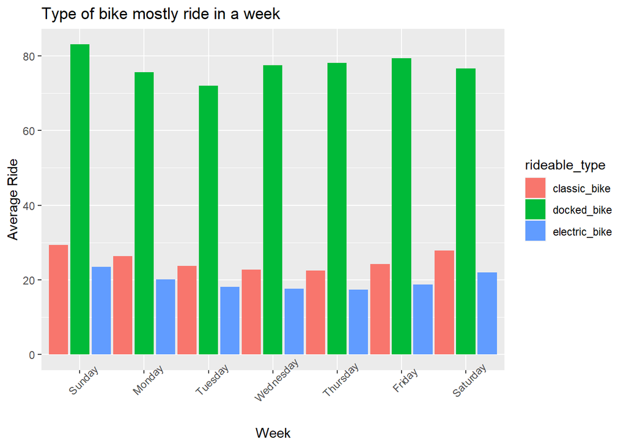

```r
bike_type_plot<-as.data.frame(bike_type)
ggplot(bike_type_plot, aes(fill=rideable_type, y=average_ride, x=weekday)) +
  geom_bar(position = position_dodge(width = 1), stat="identity") + theme(axis.text.x = element_text(angle = 45))+ ggtitle("Type of bike mostly ride in a week") +
  xlab("Week") + ylab("Average Ride")
```

## Casual workers ride more docked bikes than member riders.

```r
library(gridExtra)
```

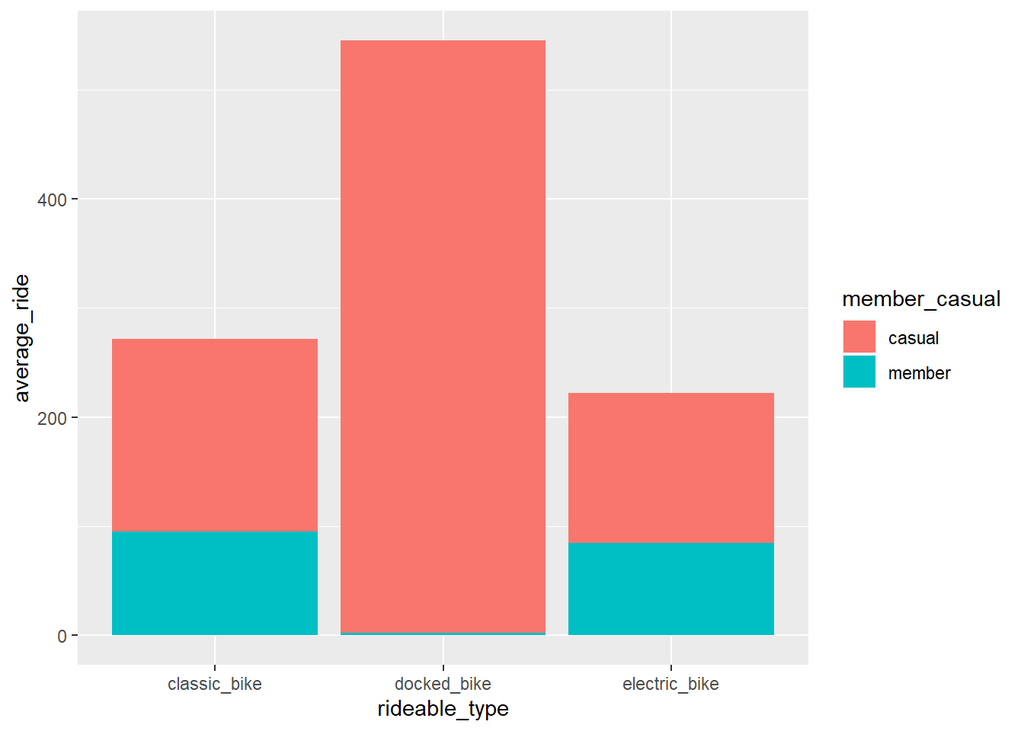

```r
library(cowplot)
bike_type_plot<-as.data.frame(bike_type)
ggplot(bike_type_plot, aes(fill=member_casual, y=average_ride, x=rideable_type)) +
  geom_bar(position="stack", stat="identity")
```

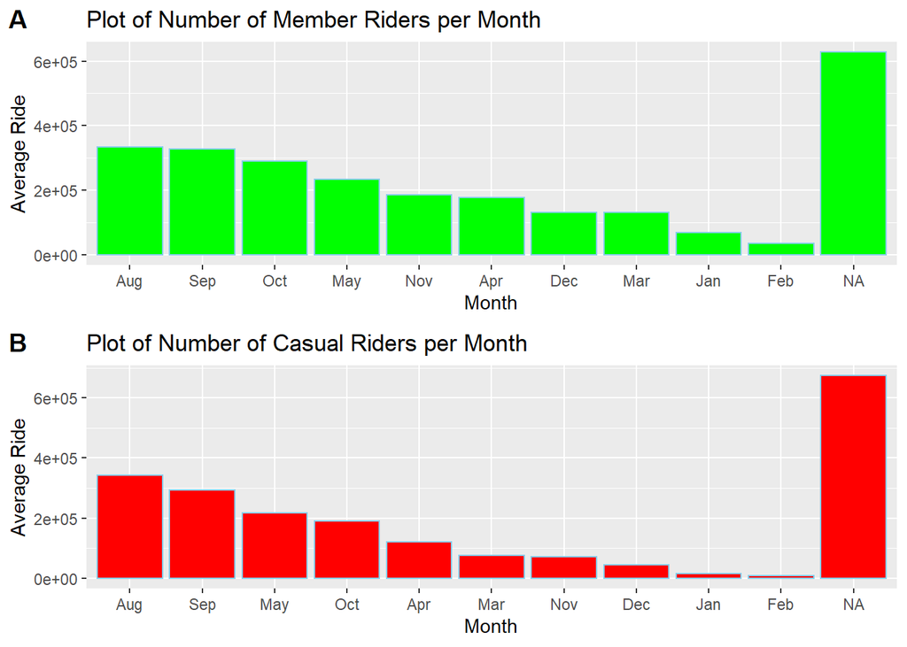

```r
library(gridExtra)
library(cowplot)

casual_count<- bik_data_new %>% group_by(month_year,member_casual) %>%
  summarise(average_ride=n()) %>%
  filter(member_casual == 'casual')
member_count<- bik_data_new %>% group_by(month_year,member_casual) %>%
  summarise(average_ride=n()) %>%
  filter(member_casual == 'member')
casual <- ggplot(data = casual_count, aes(x = reorder(month_year, -average_ride),
                      y = average_ride)) +
  geom_bar(stat="identity", color='skyblue',fill='red') + ggtitle("Plot of Number of Casual Riders per Month") +
  xlab("Month") + ylab("Average Ride")

member <- ggplot(data = member_count, aes(x = reorder(month_year, -average_ride),
                      y = average_ride)) +
  geom_bar(stat="identity", color='skyblue',fill='green') + ggtitle("Plot of Number of Member Riders per Month") +
  xlab("Month") + ylab("Average Ride")

plot_grid(member, casual, labels=c("A", "B"), ncol = 1, nrow = 2)
```

## CALCULATIONS FOR ANALYSIS

#On Average, casual riders spend more time riding in Saturdays and Sundays than Member riders.

```r
mean(bik_data_new$minute_ride)
```

```
## Time difference of 21.81153 mins
```

```r
max(bik_data_new$minute_ride)
```

```
## Time difference of 55944.15 mins
```

```r
bik_data_new %>% group_by(weekday,member_casual) %>% summarise(average_ride=mean(minute_ride)) %>%
  filter(member_casual == 'member') %>% arrange(desc(average_ride))
```

```
## # A tibble: 7 x 3
## # Groups:   weekday [7]
##   weekday   member_casual average_ride
##   <ord>     <chr>         <drtn>
## 1 Sunday    member        15.19426 mins
## 2 Saturday  member        14.81946 mins
## 3 Friday    member        12.79233 mins
## 4 Monday    member        12.72502 mins
## 5 Wednesday member        12.45793 mins
## 6 Tuesday   member        12.38767 mins
## 7 Thursday  member        12.35363 mins
```

```r
bik_data_new %>% group_by(weekday,member_casual) %>% summarise(average_ride=mean(minute_ride)) %>%
  filter(member_casual == 'casual') %>% arrange(desc(average_ride))
```

```
## # A tibble: 7 x 3
## # Groups:   weekday [7]
##   weekday   member_casual average_ride
##   <ord>     <chr>         <drtn>
## 1 Sunday    casual        37.60286 mins
## 2 Saturday  casual        34.87188 mins
## 3 Monday    casual        32.63681 mins
## 4 Friday    casual        30.91843 mins
## 5 Tuesday   casual        28.80295 mins
## 6 Wednesday casual        28.26925 mins
## 7 Thursday  casual        28.01063 mins
```

```r
bik_data_new %>% group_by(weekday) %>% count(member_casual) %>%
  filter(member_casual == 'member')%>% arrange(n)
```

```
## # A tibble: 7 x 3
## # Groups:   weekday [7]
##   weekday   member_casual      n
##   <ord>     <chr>          <int>
## 1 Sunday    member        311220
## 2 Monday    member        346481
## 3 Saturday  member        357078
## 4 Friday    member        365782
## 5 Thursday  member        373471
## 6 Tuesday   member        388131
## 7 Wednesday member        397688
```

```r
bik_data_new %>% group_by(weekday) %>% count(member_casual) %>%
  filter(member_casual == 'casual') %>% arrange(n)
```

```
## # A tibble: 7 x 3
## # Groups:   weekday [7]
##   weekday   member_casual      n
##   <ord>     <chr>          <int>
## 1 Tuesday   casual        214935
## 2 Wednesday casual        218132
## 3 Thursday  casual        224207
## 4 Monday    casual        228934
## 5 Friday    casual        290040
## 6 Sunday    casual        403762
## 7 Saturday  casual        468325
```

```r
bik_data_new %>% group_by(hours,weekday) %>% count(member_casual) %>%
  filter(member_casual == 'casual',weekday == 'Wednesday') %>% arrange(n)
```

```
## # A tibble: 24 x 4
## # Groups:   hours, weekday [24]
##    hours weekday   member_casual     n
##    <chr> <ord>     <chr>         <int>
##  1 04    Wednesday casual          444
##  2 03    Wednesday casual          466
##  3 02    Wednesday casual          699
##  4 01    Wednesday casual         1113
##  5 05    Wednesday casual         1167
##  6 00    Wednesday casual         2453
##  7 06    Wednesday casual         3128
##  8 23    Wednesday casual         5263
##  9 07    Wednesday casual         6248
## 10 09    Wednesday casual         6574
## # ... with 14 more rows
```

##The date zone is to find peak hours, “True” means hours is PM and “False” means hours is AM.

```r
bik_data_new$date_zone<-lubridate::pm(bik_data_new$startdate)

bik_data_new %>% group_by(hours,weekday,date_zone) %>% count(member_casual) %>%
  filter(member_casual == 'casual',weekday == 'Sunday') %>% arrange(desc(n))
```

```
## # A tibble: 24 x 5
## # Groups:   hours, weekday, date_zone [24]
##    hours weekday date_zone member_casual     n
##    <chr> <ord>   <lgl>     <chr>         <int>
##  1 15    Sunday  TRUE      casual        36007
##  2 14    Sunday  TRUE      casual        35223
##  3 13    Sunday  TRUE      casual        34712
##  4 16    Sunday  TRUE      casual        33769
##  5 12    Sunday  TRUE      casual        32092
##  6 17    Sunday  TRUE      casual        30328
##  7 11    Sunday  FALSE     casual        27966
##  8 18    Sunday  TRUE      casual        24663
##  9 10    Sunday  FALSE     casual        20876
## 10 19    Sunday  TRUE      casual        19038
## # ... with 14 more rows
```

```r
bik_data_new %>% group_by(hours,weekday,date_zone) %>% count(member_casual) %>%
  filter(member_casual == 'casual',weekday == 'Saturday') %>% arrange(desc(n))
```

```
## # A tibble: 24 x 5
## # Groups:   hours, weekday, date_zone [24]
##    hours weekday  date_zone member_casual     n
##    <chr> <ord>    <lgl>     <chr>         <int>
##  1 14    Saturday TRUE      casual        39407
##  2 13    Saturday TRUE      casual        39405
##  3 15    Saturday TRUE      casual        38129
##  4 16    Saturday TRUE      casual        36637
##  5 12    Saturday TRUE      casual        36440
##  6 17    Saturday TRUE      casual        34081
##  7 11    Saturday FALSE     casual        30975
##  8 18    Saturday TRUE      casual        30826
##  9 19    Saturday TRUE      casual        24749
## 10 10    Saturday FALSE     casual        23727
## # ... with 14 more rows
```

# ANALYSIS SUMMARY

1. Casual riders ride more time on average during Sunday and Saturday
2. There are on average casual members riding 34.87 min on Saturday and 37.60 min Sunday. Member riders do 15.19 min on Sunday and 14.82 min on saturday
3. Casual members ride more docked bicycles than any other type of bicycle.

##RECOMENDATION

1. Based on my analysis, I will recommend more docked bycicles be made available.
2. There can also be some free ride in between 1pm and 2pm for casual riders members who switch to member riders.
3. Membership prices can be subsidized in the summer to get more casual members switch to member riders.